# Business Problem

Data Contains Age, Race, Educational detail and Labour earning for 1974, 1975. We need to predict the labours earning for 1978

### Solution Approach:

As we need to predict Labour earning for 1978 which is continuous in nature, Linear Regression can be used for prediction

### Multiple Linear Regression

Now you know how to build a model with one X (feature variable) and Y (response variable). But what if you have three feature variables, or may be 10 or 100? Building a separate model for each of them, combining them, and then understanding them will be a very difficult and next to impossible task. By using multiple linear regression, you can build models between a response variable and many feature variables.

Let's see how to do that.

### Step 1 : Importing LIbraries and Understanding Data

```python
import pandas as pd
```

```python
# Importing LabourTrainingEvaluationData.csv
LabourData = pd.read_csv('LabourEarningPrediction.csv')
```

```python
# Looking at the first five rows
LabourData.head()
```

|  | Age | Eduacation | Race | Hisp | MaritalStatus | Nodeg | Earnings_1974 | Earnings_1975 | Earnings_1978 |
| --- | --- | --- | --- | --- | --- | --- | --- | --- | --- |
| 0 | 45 | LessThanHighSchool | NotBlack | NotHispanic | Married | 1 | 21516.670 | 25243.550 | 25564.670 |
| 1 | 21 | Intermediate | NotBlack | NotHispanic | NotMarried | 0 | 3175.971 | 5852.565 | 13496.080 |
| 2 | 38 | HighSchool | NotBlack | NotHispanic | Married | 0 | 23039.020 | 25130.760 | 25564.670 |
| 3 | 48 | LessThanHighSchool | NotBlack | NotHispanic | Married | 1 | 24994.370 | 25243.550 | 25564.670 |
| 4 | 18 | LessThanHighSchool | NotBlack | NotHispanic | Married | 1 | 1669.295 | 10727.610 | 9860.869 |

```python
# Looking at the last five rows
LabourData.tail()
```

|  | Age | Eduacation | Race | Hisp | MaritalStatus | Nodeg | Earnings_1974 | Earnings_1975 | Earnings_1978 |
| --- | --- | --- | --- | --- | --- | --- | --- | --- | --- |
| 15987 | 22 | HighSchool | black | NotHispanic | NotMarried | 0 | 3975.352 | 6801.435 | 2757.438 |
| 15988 | 20 | HighSchool | black | NotHispanic | Married | 0 | 1445.939 | 11832.240 | 6895.072 |
| 15989 | 37 | HighSchool | NotBlack | NotHispanic | NotMarried | 0 | 1733.951 | 1559.371 | 4221.865 |
| 15990 | 47 | LessThanHighSchool | NotBlack | NotHispanic | Married | 1 | 16914.350 | 11384.660 | 13671.930 |
| 15991 | 40 | LessThanHighSchool | NotBlack | NotHispanic | NotMarried | 1 | 13628.660 | 13144.550 | 7979.724 |

#### Lets check the data type

```python
# What type of values are stored in the columns?
LabourData.info()
```

```
<class 'pandas.core.frame.DataFrame'>
RangeIndex: 15992 entries, 0 to 15991
Data columns (total 9 columns):
Age              15992 non-null int64
Eduacation       15992 non-null object
Race             15992 non-null object
Hisp             15992 non-null object
MaritalStatus    15992 non-null object
Nodeg            15992 non-null int64
Earnings_1974    15992 non-null float64
Earnings_1975    15992 non-null float64
Earnings_1978    15992 non-null float64
dtypes: float64(3), int64(2), object(4)
memory usage: 1.1+ MB
```

### Let's check the summary fo data

```python
# Let's look at some statistical information about our dataframe.
LabourData.describe()
```

|  | Age | Nodeg | Earnings_1974 | Earnings_1975 | Earnings_1978 |
| --- | --- | --- | --- | --- | --- |
| count | 15992.000000 | 15992.000000 | 15992.000000 | 15992.000000 | 15992.000000 |
| mean | 33.225238 | 0.295835 | 14016.800304 | 13650.803376 | 14846.659673 |
| std | 11.045216 | 0.456432 | 9569.795893 | 9270.403225 | 9647.391524 |
| min | 16.000000 | 0.000000 | 0.000000 | 0.000000 | 0.000000 |
| 25% | 24.000000 | 0.000000 | 4403.452250 | 4398.823000 | 5669.298000 |
| 50% | 31.000000 | 0.000000 | 15123.580000 | 14557.110000 | 16421.975000 |
| 75% | 42.000000 | 1.000000 | 23584.180000 | 22923.737500 | 25564.670000 |
| max | 55.000000 | 1.000000 | 25862.320000 | 25243.550000 | 25564.670000 |

### Step 2: Visualising Data

```python
import matplotlib.pyplot as plt
import seaborn as sns
%matplotlib inline
```

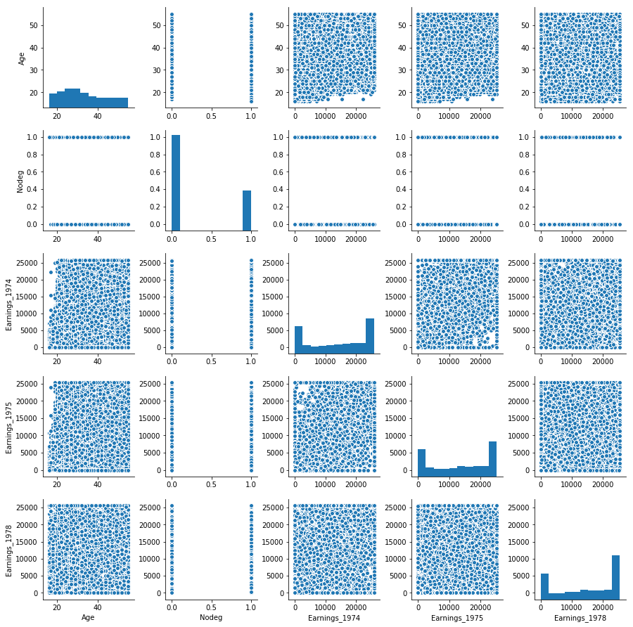

```python
# Let's plot a pair plot of all numerical variables in our dataframe
sns.pairplot(LabourData)
```

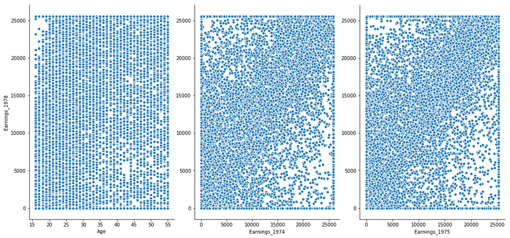

```python
# Visualise the relationship between the features and the response using scatterplots
sns.pairplot(LabourData, x_vars=['Age','Earnings_1974','Earnings_1975'], y_vars='Earnings_1978',
             size=7, aspect=0.7, kind='scatter')
```

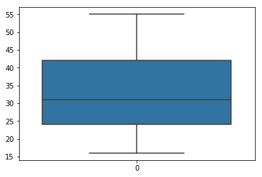

```python
sns.boxplot(data=LabourData["Age"])
```

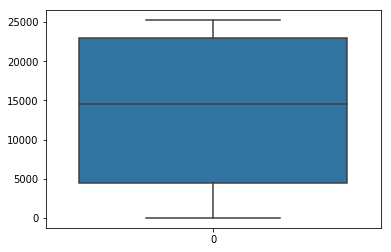

```python
sns.boxplot(data=LabourData["Earnings_1975"])
```

#### Exploration of Categorical Variables

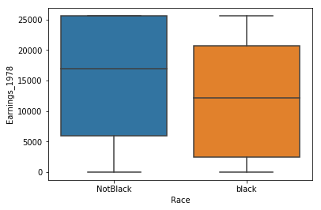

```python
sns.boxplot( x=LabourData["Race"], y=LabourData["Earnings_1978"] )
```

###### Median Earning for NonBlack is higher than Black laborus

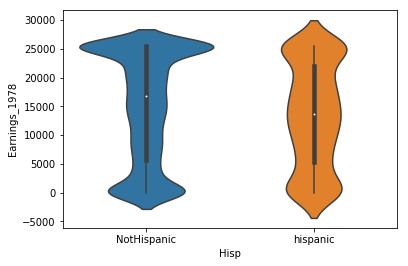

```python
sns.violinplot( x=LabourData["Hisp"], y=LabourData["Earnings_1978"] )
```

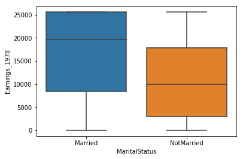

```python
sns.boxplot( x=LabourData["MaritalStatus"], y=LabourData["Earnings_1978"] )
```

###### Median Earning for Maaried laborus is higher than Unmaaried labours

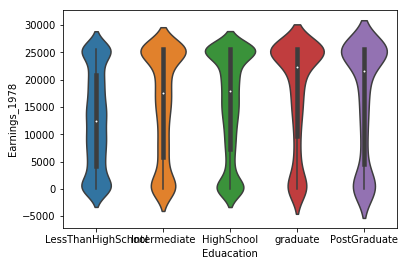

```python
sns.violinplot( x=LabourData["Eduacation"], y=LabourData["Earnings_1978"])
```

##### Seperate the Numerical and Categorical variables

Numerical Variables:

```python
LabourData_num = LabourData[['Age','Nodeg', 'Earnings_1974', 'Earnings_1975', 'Earnings_1978']]
```

Categorical Variables: The variables which are having category should be converted to dummy variables.

The Linear regression will only accept numbers so we will make dummy variables.

##### Creation of dummy variables

```python
LabourData_dummies = pd.get_dummies(LabourData[['Race', 'Hisp', 'MaritalStatus', 'Eduacation']])
```

```python
LabourData_dummies.head()
```

|  | Race_NotBlack | Race_black | Hisp_NotHispanic | Hisp_hispanic | MaritalStatus_Married | MaritalStatus_NotMarried | Eduacation_HighSchool | Eduacation_Intermediate | Eduacation_LessThanHighSchool | Eduacation_PostGraduate | Eduacation_graduate |
| --- | --- | --- | --- | --- | --- | --- | --- | --- | --- | --- | --- |
| 0 | 1 | 0 | 1 | 0 | 1 | 0 | 0 | 0 | 1 | 0 | 0 |
| 1 | 1 | 0 | 1 | 0 | 0 | 1 | 0 | 1 | 0 | 0 | 0 |
| 2 | 1 | 0 | 1 | 0 | 1 | 0 | 1 | 0 | 0 | 0 | 0 |
| 3 | 1 | 0 | 1 | 0 | 1 | 0 | 0 | 0 | 1 | 0 | 0 |
| 4 | 1 | 0 | 1 | 0 | 1 | 0 | 0 | 0 | 1 | 0 | 0 |

##### Combine Numerical and Dummy variables

```python
LabourData_combined = pd.concat([LabourData_num, LabourData_dummies], axis=1)
```

```python
LabourData_combined.head()
```

|  | Age | Nodeg | Earnings_1974 | Earnings_1975 | Earnings_1978 | Race_NotBlack | Race_black | Hisp_NotHispanic | Hisp_hispanic | MaritalStatus_Married | MaritalStatus_NotMarried | Eduacation_HighSchool | Eduacation_Intermediate | Eduacation_LessThanHighSchool | Eduacation_PostGraduate | Eduacation_graduate |
| --- | --- | --- | --- | --- | --- | --- | --- | --- | --- | --- | --- | --- | --- | --- | --- | --- |
| 0 | 45 | 1 | 21516.670 | 25243.550 | 25564.670 | 1 | 0 | 1 | 0 | 1 | 0 | 0 | 0 | 1 | 0 | 0 |
| 1 | 21 | 0 | 3175.971 | 5852.565 | 13496.080 | 1 | 0 | 1 | 0 | 0 | 1 | 0 | 1 | 0 | 0 | 0 |
| 2 | 38 | 0 | 23039.020 | 25130.760 | 25564.670 | 1 | 0 | 1 | 0 | 1 | 0 | 1 | 0 | 0 | 0 | 0 |
| 3 | 48 | 1 | 24994.370 | 25243.550 | 25564.670 | 1 | 0 | 1 | 0 | 1 | 0 | 0 | 0 | 1 | 0 | 0 |
| 4 | 18 | 1 | 1669.295 | 10727.610 | 9860.869 | 1 | 0 | 1 | 0 | 1 | 0 | 0 | 0 | 1 | 0 | 0 |

# Step 3 : Splitting the data in Training and Test set

Using sklearn we split 70% of our data into training set and rest in test set.

Setting random_state will give the same training and test set everytime on running the code.

```python
# Putting feature variable to X
X = LabourData_combined[['Age', 'Earnings_1974', 'Earnings_1975', 'Race_NotBlack', 'Race_black',
                         'Hisp_NotHispanic', 'Hisp_hispanic','MaritalStatus_Married',
                         'MaritalStatus_NotMarried', 'Eduacation_HighSchool', 'Eduacation_Intermediate',
                         'Eduacation_LessThanHighSchool', 'Eduacation_PostGraduate', 'Eduacation_graduate']]

# Putting response variable to y
y = LabourData['Earnings_1978']
```

```python
#random_state is the seed used by the random number generator. It can be any integer.
from sklearn.model_selection import train_test_split
X_train, X_test, y_train, y_test = train_test_split(X, y, train_size=0.7 , random_state=100)
```

[output not shown]

# Step 4 : Performing Linear Regression

```python
from sklearn.linear_model import LinearRegression
```

```python
# Representing LinearRegression as lr(Creating LinearRegression Object)
lm = LinearRegression()
```

```python
# fit the model to the training data
lm.fit(X_train,y_train)
```

```
LinearRegression(copy_X=True, fit_intercept=True, n_jobs=1, normalize=False)
```

# Step 5 : Model Evaluation

```python
# print the intercept
print(lm.intercept_)
```

```
7444.55415963
```

```python
# Let's see the coefficient
coeff_df = pd.DataFrame(lm.coef_,X_test.columns,columns=['Coefficient'])
coeff_df
```

|  | Coefficient |
| --- | --- |
| Age | -105.198175 |
| Earnings_1974 | 0.287449 |
| Earnings_1975 | 0.477042 |
| Race_NotBlack | 455.276440 |
| Race_black | -455.276440 |
| Hisp_NotHispanic | 318.966611 |
| Hisp_hispanic | -318.966611 |
| MaritalStatus_Married | -6.798382 |
| MaritalStatus_NotMarried | 6.798382 |
| Eduacation_HighSchool | -348.648766 |
| Eduacation_Intermediate | -212.161446 |
| Eduacation_LessThanHighSchool | -525.158971 |
| Eduacation_PostGraduate | 649.237226 |
| Eduacation_graduate | 436.731957 |

From the above result we may infern that if Age increses by 1 unit

it will affect Earnings_1978 by -105.198175 units.

# Step 6 : Predictions

```python
# Making predictions using the model
y_pred = lm.predict(X_test)
```

# Step 7: Model Performance Metrics

### Coefficient of Determination (R square)

```python
from IPython.display import Image
```

```python
display(Image("D:\\2_StudyMaterial\\AB\\R2.jpg"))
```

[output not shown]

```python
display(Image("D:\\2_StudyMaterial\\AB\\R2_1.jpg"))
```

[output not shown]

```python
from sklearn.metrics import mean_squared_error, r2_score
mse = mean_squared_error(y_test, y_pred)
r_squared = r2_score(y_test, y_pred)
```

```python
from math import sqrt
rmse = sqrt(mse)
```

```python
print('Mean_Squared_Error :' ,mse)
print('Root_Mean_Squared_Error :' ,rmse)
print('r_square_value :',r_squared)
```

```
Mean_Squared_Error : 50283398.7266
Root_Mean_Squared_Error : 7091.078812610237
r_square_value : 0.463928908706
```

If the value of R2 is 0.463 then this suggests that 46.3% of the variation in Y can be explained with the help of given explanatory variables in that model. In other words, it explains the proportion of variation in the dependent variable that is explained by the independent variables.

On addition of a new variable the error is sure to decrease, thus R square always increases whenever a new variable is added to our model. This may not describe the importance of a variable

### Adjusted R square:

```python
display(Image("D:\\2_StudyMaterial\\AB\\AdjR2.jpg"))
```

[output not shown]

Or

```python
display(Image("D:\\2_StudyMaterial\\AB\\AdjR2_1.jpg"))
```

[output not shown]

where k is the no. of regressors or predictors.

#### Hence adjusted R square will always be less than or equal to R square.

Thus as a general thumb rule if adjusted R square increases when a new variable is added to the model, the variable should remain in the model.

If the adjusted R square decreases when the new variable is added then the variable should not remain in the mode

### Multicollinearity

If independent valriables Xi’s are highly correlated then |X’X| will be close to 0 and hence inverse of (X’X) will not exist or will be indefinitely large. Mathematically, which will be indefinitely large in presence of multicollinearity. Long story in short, multicollinearity increases the estimate of standard error of regression coefficients which makes some variables statistically insignificant when they should be significant.

How can you detect multicollinearity!!

##### Correlation Method:

By calculating the correlation coefficients between the variables we can get to know about the extent of multicollinearity in the data.

##### VIF (Variance Inflation Factor) Method:

Firstly we fit a model with all the variables and then calculate the variance inflation factor (VIF) for each variable. VIF measures how much the variance of an estimated regression coefficient increases if your predictors are correlated. The higher the value of VIF for ith regressor, the more it is highly correlated to other variables

### Optional Step : Checking for P-value Using STATSMODELS

```python
import statsmodels.api as sm
X_train_sm = X_train
#Unlike SKLearn, statsmodels don't automatically fit a constant,
#so you need to use the method sm.add_constant(X) in order to add a constant.
X_train_sm = sm.add_constant(X_train_sm)
# create a fitted model in one line
lm_1 = sm.OLS(y_train,X_train_sm).fit()

# print the coefficients
lm_1.params
```

```python
print(lm_1.summary())
```

```
                            OLS Regression Results
==============================================================================
Dep. Variable:          Earnings_1978   R-squared:                       0.480
Model:                            OLS   Adj. R-squared:                  0.479
Method:                 Least Squares   F-statistic:                     1031.
Date:                Thu, 24 Jan 2019   Prob (F-statistic):               0.00
Time:                        21:40:56   Log-Likelihood:            -1.1490e+05
No. Observations:               11194   AIC:                         2.298e+05
Df Residuals:                   11183   BIC:                         2.299e+05
Df Model:                          10
Covariance Type:            nonrobust
=================================================================================================
                                    coef    std err          t      P>|t|      [0.025      0.975]
-------------------------------------------------------------------------------------------------
const                          2757.2423    103.455     26.652      0.000    2554.452    2960.033
Age                            -105.1982      6.927    -15.187      0.000    -118.776     -91.620
Earnings_1974                     0.2874      0.015     19.804      0.000       0.259       0.316
Earnings_1975                     0.4770      0.015     32.677      0.000       0.448       0.506
Race_NotBlack                  1833.8976    115.178     15.922      0.000    1608.129    2059.666
Race_black                      923.3447    155.866      5.924      0.000     617.821    1228.869
Hisp_NotHispanic               1697.5878    116.524     14.569      0.000    1469.179    1925.996
Hisp_hispanic                  1059.6545    158.157      6.700      0.000     749.639    1369.670
MaritalStatus_Married          1371.8228    109.490     12.529      0.000    1157.203    1586.443
MaritalStatus_NotMarried       1385.4195     87.537     15.827      0.000    1213.831    1557.008
Eduacation_HighSchool           202.7997    116.208      1.745      0.081     -24.988     430.587
Eduacation_Intermediate         339.2870    150.406      2.256      0.024      44.465     634.109
Eduacation_LessThanHighSchool    26.2895    128.490      0.205      0.838    -225.573     278.152
Eduacation_PostGraduate        1200.6857    235.369      5.101      0.000     739.322    1662.050
Eduacation_graduate             988.1804    196.918      5.018      0.000     602.187    1374.174
==============================================================================
Omnibus:                     1109.071   Durbin-Watson:                   2.003
Prob(Omnibus):                  0.000   Jarque-Bera (JB):             1997.641
Skew:                          -0.683   Prob(JB):                         0.00
Kurtosis:                       4.555   Cond. No.                     1.24e+21
==============================================================================

Warnings:
[1] Standard Errors assume that the covariance matrix of the errors is correctly specified.
[2] The smallest eigenvalue is 4.04e-30. This might indicate that there are
strong multicollinearity problems or that the design matrix is singular.
```

```python
import matplotlib.pyplot as plt
import seaborn as sns
%matplotlib inline
```

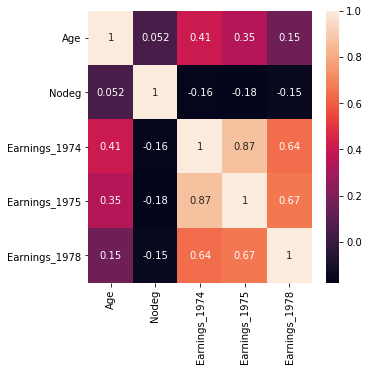

```python
plt.figure(figsize = (5,5))
sns.heatmap(LabourData_num.corr(),annot = True)
```

# Step 8 : Implementing the results

```
Text(0,0.5,'Earnings_1978')
```

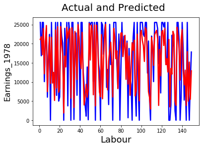

```python
#Actual vs Predicted
# Check for the forst 150 observations

c = [i for i in range(1,150,1)]
fig = plt.figure()
plt.plot(c,y_test[1:150], color="blue", linewidth=2.5, linestyle="-")
plt.plot(c,y_pred[1:150], color="red",  linewidth=2.5, linestyle="-")
fig.suptitle('Actual and Predicted', fontsize=20)              # Plot heading
plt.xlabel('Labour', fontsize=18)                               # X-label
plt.ylabel('Earnings_1978', fontsize=16)                               # Y-label
```

```
Text(0,0.5,'Actual - Predicted')
```

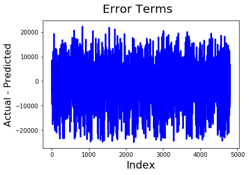

```python
# Error terms
c = [i for i in range(1,4799,1)]
fig = plt.figure()
plt.plot(c,y_test-y_pred, color="blue", linewidth=2.5, linestyle="-")
fig.suptitle('Error Terms', fontsize=20)              # Plot heading
plt.xlabel('Index', fontsize=18)                      # X-label
plt.ylabel('Actual - Predicted', fontsize=16)                # Y-label
```

```python
print('Mean_Squared_Error :' ,mse)
print('r_square_value :',r_squared)
```

```
Mean_Squared_Error : 50283398.7266
r_square_value : 0.463928908706
```

```python
X_train_final = X_train
#Unlike SKLearn, statsmodels don't automatically fit a constant,
#so you need to use the method sm.add_constant(X) in order to add a constant.
X_train_final = sm.add_constant(X_train_final)
# create a fitted model in one line
lm_final = sm.OLS(y_train,X_train_final).fit()

print(lm_final.summary())
```

```
                            OLS Regression Results
==============================================================================
Dep. Variable:          Earnings_1978   R-squared:                       0.480
Model:                            OLS   Adj. R-squared:                  0.479
Method:                 Least Squares   F-statistic:                     1031.
Date:                Thu, 24 Jan 2019   Prob (F-statistic):               0.00
Time:                        21:46:25   Log-Likelihood:            -1.1490e+05
No. Observations:               11194   AIC:                         2.298e+05
Df Residuals:                   11183   BIC:                         2.299e+05
Df Model:                          10
Covariance Type:            nonrobust
=================================================================================================
                                    coef    std err          t      P>|t|      [0.025      0.975]
-------------------------------------------------------------------------------------------------
const                          2757.2423    103.455     26.652      0.000    2554.452    2960.033
Age                            -105.1982      6.927    -15.187      0.000    -118.776     -91.620
Earnings_1974                     0.2874      0.015     19.804      0.000       0.259       0.316
Earnings_1975                     0.4770      0.015     32.677      0.000       0.448       0.506
Race_NotBlack                  1833.8976    115.178     15.922      0.000    1608.129    2059.666
Race_black                      923.3447    155.866      5.924      0.000     617.821    1228.869
Hisp_NotHispanic               1697.5878    116.524     14.569      0.000    1469.179    1925.996
Hisp_hispanic                  1059.6545    158.157      6.700      0.000     749.639    1369.670
MaritalStatus_Married          1371.8228    109.490     12.529      0.000    1157.203    1586.443
MaritalStatus_NotMarried       1385.4195     87.537     15.827      0.000    1213.831    1557.008
Eduacation_HighSchool           202.7997    116.208      1.745      0.081     -24.988     430.587
Eduacation_Intermediate         339.2870    150.406      2.256      0.024      44.465     634.109
Eduacation_LessThanHighSchool    26.2895    128.490      0.205      0.838    -225.573     278.152
Eduacation_PostGraduate        1200.6857    235.369      5.101      0.000     739.322    1662.050
Eduacation_graduate             988.1804    196.918      5.018      0.000     602.187    1374.174
==============================================================================
Omnibus:                     1109.071   Durbin-Watson:                   2.003
Prob(Omnibus):                  0.000   Jarque-Bera (JB):             1997.641
Skew:                          -0.683   Prob(JB):                         0.00
Kurtosis:                       4.555   Cond. No.                     1.24e+21
==============================================================================

Warnings:
[1] Standard Errors assume that the covariance matrix of the errors is correctly specified.
[2] The smallest eigenvalue is 4.04e-30. This might indicate that there are
strong multicollinearity problems or that the design matrix is singular.
```

#### Variance Inflation Factor

Variance inflation factor (VIF) for an explanatory variable is given 1/(1-R^2 ) .

Here, we take that particular X as response variable and all other explanatory

variables as independent variables. So, we run a regression between one of

those explanatory variables with remaining explanatory variables.

```python
from statsmodels.stats.outliers_influence import variance_inflation_factor
```

```python
# For each X, calculate VIF and save in dataframe
vif = pd.DataFrame()
vif["VIF Factor"] = [variance_inflation_factor(X.values, i) for i in range(X.shape[1])]
vif["features"] = X.columns
```

```python
vif.round(2)
```

|  | VIF Factor | features |
| --- | --- | --- |
| 0 | 1.370000 | Age |
| 1 | 4.410000 | Earnings_1974 |
| 2 | 4.180000 | Earnings_1975 |
| 3 | inf | Race_NotBlack |
| 4 | inf | Race_black |
| 5 | inf | Hisp_NotHispanic |
| 6 | inf | Hisp_hispanic |
| 7 | inf | MaritalStatus_Married |
| 8 | inf | MaritalStatus_NotMarried |
| 9 | inf | Eduacation_HighSchool |
| 10 | inf | Eduacation_Intermediate |
| 11 | inf | Eduacation_LessThanHighSchool |
| 12 | inf | Eduacation_PostGraduate |
| 13 | inf | Eduacation_graduate |

#### Variance Inflation Factor

Please read more about VIF and the cut off of Variance

The thumb rule is VIF greater than 10 should be removed.